# Zadanie 3

### Firma chce wdrożyć odpowiednią komunikację marketingową dla klientów, u których można stwierdzić szanse kupna produktu premium. Stwórz model klasyfikacyjny, którego celem jest przewidywanie którzy klienci mogą wykupić usługę premium. Jaka jest skuteczność takiego modelu? Jakie zmienne mają największy wpływ na decyzję o kupnie?

```r
suppressMessages(library(vroom))
suppressMessages(library(lubridate))
suppressMessages(library(xgboost))
suppressMessages(library(mice))
suppressMessages(library(xgboost))
suppressMessages(library(matrixStats))
suppressMessages(library(Matrix))
suppressMessages(library(tidyverse))
source("PlotVariableSparsity.R")
source("PlotVariableCardinality.R")
```

```r
data <- readRDS("klienci.RDS")
```

[figure not shown]

```
##      klient_id wyksztalcenie czy_samochod plec czy_kupil czy_w_bazie_klientow
## 5125         1             1            1    1         1                    1
## 443          1             1            1    1         1                    1
## 158          1             1            1    1         1                    1
## 17           1             1            1    1         1                    1
## 104          1             1            1    1         1                    1
## 8            1             1            1    1         1                    1
## 3            1             1            1    1         1                    1
## 80           1             1            1    1         1                    1
## 6            1             1            1    1         1                    1
## 1            1             1            1    1         1                    1
## 1            1             1            1    1         1                    1
## 2            1             1            1    1         1                    1
## 45           1             1            1    1         1                    1
## 4            1             1            1    1         1                    1
```

[output cut: 111 more lines]

```r
md.pattern(data)
```

Imputacja brakow danych za pomoca predictive mean matching, to uniwersalna metoda a w sytuacji gdy mamy tak malo danych ciezko ocenic z jakim mechanizmem powstania brakow danych mamy do czynienia (MAR, MCAR, MNAR)

```r
imputed_data <- suppressMessages(mice(data, m=5, maxit = 50, method = 'pmm', seed = 500))
```

```
##
##  * Please inspect the loggedEvents
```

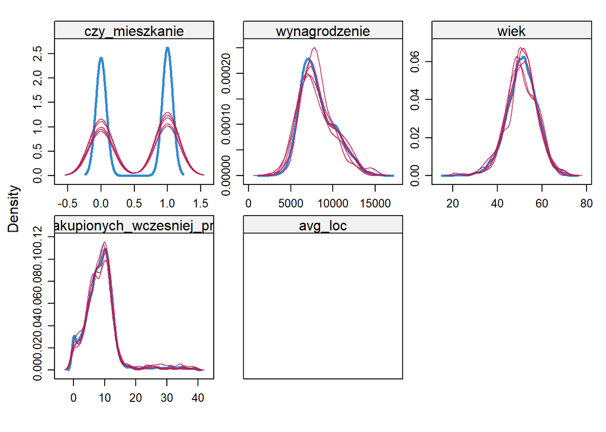

```r
densityplot(imputed_data)
```

```r
dt <- complete(imputed_data,3)
onehotmatrix <- model.matrix(object = czy_kupil ~ ., data = dt)
```

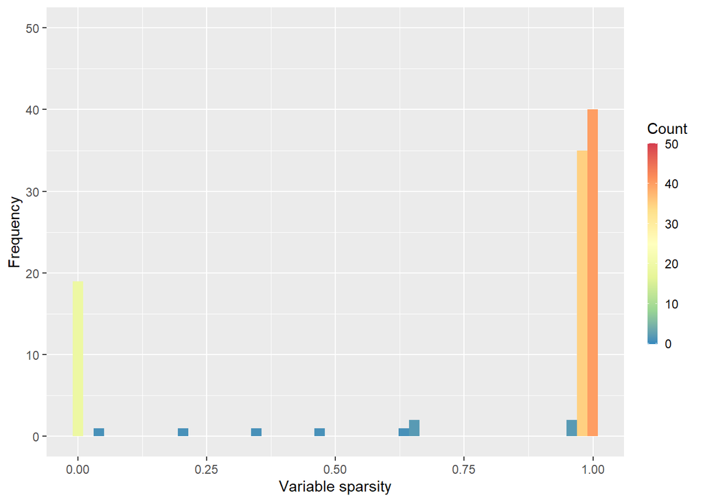

```r
PlotVariableSparsity(onehotmatrix)
```

Rzadkosc 0/1 jest akceptalna, wiekszym problemem rozrzedzenia zbioru moze byc ilosc feature’ow wzgledem ilosci obserwacji

[output not shown]

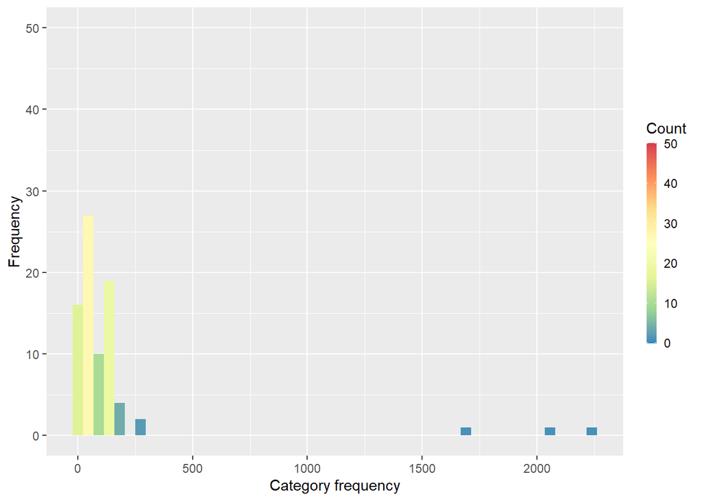

```r
PlotVariableCardinality(dt,"czy_kupil")
```

Niektore kategorie maja bardzo niewiele obserwacji, nalezy pomyslec nad redukcja ilosci kategorii poprzez inne kodowanie zmiennych, z drugiej nalezy pamietac ze i tak mamy zaledwie 6000 obserwacji

```r
table(dt$avg_loc)
```

```
##
## CZ051 CZ071 CZ080 DE80N DED2D PL113 PL114 PL115 PL116 PL117 PL127 PL128 PL129
##     1     2     4     3     5   103    82    52    36    24   111   118   127
## PL12A PL12B PL12C PL12D PL12E PL213 PL214 PL217 PL218 PL219 PL21A PL224 PL225
##   132    36   113    38    11    84   140    23    51    40    68   124   153
## PL227 PL228 PL229 PL22A PL22B PL22C PL311 PL312 PL314 PL315 PL323 PL324 PL325
##   123   158   175   255   140   158     7    30   172    38    37    20   155
## PL326 PL331 PL332 PL343 PL344 PL345 PL411 PL414 PL415 PL416 PL417 PL418 PL424
##    49   148    29   139    20    19    28    46    76    63    50   160    81
## PL426 PL427 PL428 PL431 PL432 PL514 PL515 PL516 PL517 PL518 PL523 PL524 PL613
##    29    17   128   112   156    93    43    36    71   163    41   132   262
## PL616 PL617 PL618 PL619 PL621 PL622 PL623 PL633 PL634 PL636 PL637 PL638 SK041
##    15    42    11     6    41   125    27   116   135    33    19    36     2
```

Bardzo duzo kategorii usrednionej lokalizacji wzgledem ilosci obserwacji im odpowiadajacych.

Nalezy dokonac konwersji kodow NUTS3 do wiekszych jednostek administracyjnych NUTS2

```r
for(i in 1:length(dt$avg_loc)){
  if(!is.na(dt$avg_loc[i])){
    if(nchar(dt$avg_loc[i]) == 5){
      dt$avg_loc[i] <- substr(dt$avg_loc[i],1,nchar(dt$avg_loc[i])-1)
    }
  }
}
```

Przypisanie brakow danych i zagranicy to oddzielnej kategorii, z uwagi na to, jak nieliczne to sa kategorie

```r
for(i in 1:length(dt$avg_loc)){
  if(is.na(dt$avg_loc[i])){
    dt$avg_loc[i] <- "OTHER"
  }

  if(!grepl("PL",dt$avg_loc[i])){
    dt$avg_loc[i] <- "OTHER"
  }

}
```

```r
table(dt$avg_loc)
```

```
##
## OTHER  PL11  PL12  PL21  PL22  PL31  PL32  PL33  PL34  PL41  PL42  PL43  PL51
##    69   297   686   406  1286   247   261   177   178   423   255   268   406
##  PL52  PL61  PL62  PL63
##   173   336   193   339
```

```r
onehotmatrix <- model.matrix(object = czy_kupil ~ ., data = dt)
temp_df <- data.frame(onehotmatrix)
temp_df <- temp_df %>% left_join(dt)
col.scale <- colMaxs(abs(onehotmatrix))
x.sc <- sweep(onehotmatrix, 2, col.scale, "/")

dtrain <- xgb.DMatrix(Matrix(x.sc, sparse = TRUE),
                      label = as.integer(temp_df$czy_kupil))
```

```r
xgb.params <- list(
  "booster" = "gbtree",
  "eta" = 0.05,
  "max_depth" = 4,
  "subsample" = 0.632,
  "colsample_bytree" = 0.4,
  "colsample_bylevel" = 0.6,
  "min_child_weight" = 1,
  "gamma" = 0,
  "lambda" = 0,
  "alpha" = 0,
  "objective" = "binary:logistic",
  "eval_metric" = "auc",
  "silent" = 1,
  "nthread" = 4,
  "num_parallel_tree" = 5
)
```

```r
set.seed(2020)
cv.out <-
  xgb.cv(
    params = xgb.params,
    data = dtrain,
    nrounds = 1.5e3,
    metrics = list('error'),
    nfold = 5,
    prediction = FALSE,
    verbose = TRUE,
    showsd = FALSE,
    print.every.n = 10,
    early.stop.round = 10,
    maximize = TRUE
  )
```

```
## Multiple eval metrics are present. Will use test_error for early stopping.
## Will train until test_error hasn't improved in 10 rounds.
##
## Stopping. Best iteration:
```

```r
cv.out
```

```
## ##### xgb.cv 5-folds
##  iter train_auc_mean train_auc_std train_error_mean train_error_std
##     1      0.7441068   0.027252616        0.1698336     0.006641525
##     2      0.7763606   0.019976463        0.1709584     0.003140017
##     3      0.7895648   0.005170803        0.1674168     0.005060936
##     4      0.7928868   0.005799145        0.1695422     0.006664379
##     5      0.7967642   0.005632754        0.1677922     0.007872611
##     6      0.7981590   0.006152907        0.1677508     0.008920786
##     7      0.8019586   0.004156776        0.1686254     0.005524290
##     8      0.8031108   0.004495643        0.1671668     0.006229845
##     9      0.8055044   0.003540777        0.1669584     0.005818765
##    10      0.8075966   0.002954974        0.1665834     0.005708000
##    11      0.8079800   0.002391977        0.1660000     0.004542218
##    12      0.8083814   0.001692133        0.1652914     0.003625509
##  test_auc_mean test_auc_std test_error_mean test_error_std
##      0.6836462   0.04338390       0.1718396     0.01462308
##      0.7229936   0.03235654       0.1746732     0.01532128
##      0.7354614   0.02318414       0.1716716     0.01351956
##      0.7357988   0.02139765       0.1728380     0.01171497
##      0.7353528   0.02132976       0.1703374     0.01071884
##      0.7350950   0.02117575       0.1703372     0.01062341
##      0.7359602   0.02274546       0.1720058     0.01339326
##      0.7349826   0.02262331       0.1708398     0.01399771
##      0.7382008   0.02246391       0.1705074     0.01505316
##      0.7422412   0.02185761       0.1706738     0.01503158
##      0.7433908   0.02194243       0.1706740     0.01551478
##      0.7445662   0.02286285       0.1706738     0.01618079
## Best iteration:
##  iter train_auc_mean train_auc_std train_error_mean train_error_std
##     2      0.7763606    0.01997646        0.1709584     0.003140017
##  test_auc_mean test_auc_std test_error_mean test_error_std
##      0.7229936   0.03235654       0.1746732     0.01532128
```

0.723 auc na zbiorze testowym przy odchyleniu standardowym 0.032 przy 5 krotnej cross-validacji, przyzwoity wynik jak na tak maly zbior danych

Bez przekodowania zmiennej avg_loc model uzyskiwal maksymalne auc na zbiorze testowym na poziomie 0.7, zatem zmiana ta poprawila model

```r
xgb.model <- xgb.train(data = dtrain,
                       params = xgb.params,
                       nrounds = 500)
```

[output not shown]

```r
var.imp <- xgb.importance(colnames(x.sc), model = xgb.model) %>%
  mutate(Feature = gsub('[0-9]+', '', Feature)) %>%
  group_by(Feature) %>%
  summarise(Importance = quantile(Gain, 0.9)) %>%
  ungroup() %>%
  arrange(desc(Importance)) %>%
  mutate(Importance = round(100 * Importance / sum(Importance), 2))
var.imp
```

| Feature | Importance |
| --- | --- |
| wiek | 13.32 |
| wynagrodzenie | 9.81 |
| plec | 7.16 |
| session_length_mean | 6.59 |
| session_length_median | 5.46 |
| max_min_dist | 5.45 |
| session_length_percentile | 5.30 |
| session_length_variance | 5.18 |
| nclient | 4.73 |
| avg_diff_days | 4.43 |

[output cut: 15 more lines]

Na decyzje o kupnie najwiekszy wplyw ma

1. wiek (wysoka istotnosc parametru bylo widac juz na etapie ekspolarcji zbioru danych)
2. wynagrodzenie
3. plec
4. statystyki dlugosc uzywania aplikacji

Przypuszczalnie czestotliowsc uzywania aplikacji ma wiekszy wplyw niż wynikaloby to z importance matrix z uwagi na to, ze jest ona reprezentowana przez rozne, silnie wspolniniowe zmienne (mialem kilka pomyslow w jaki sposob zakodowac czestotliwosc uzywania aplikacji). Xgboost jak wszystkie modele drzewiaste nie jest wrazliwy wspolliniowosc zmiennych pod katem jakosci tworzenia modelu, wspolliniowosc ma jednak wplyw na ksztalt importance matrix.